# Analyzing Baseball Data with R - Chapter 1d

## Lahman Database Questions

### Home Runs and Strikeouts

*What is the averaged number of home runs per game recorded in each decade? Does the rate of strikeouts show any correlation with the rate of home runs?*

First, we need to get the data for home runs and strike outs per game.

```r
# get Lahman team data
teams = Lahman::Teams

# get home runs by decade
home_run_by_decade = teams %>%
  mutate(decade = paste(substr(yearID, 1, 3), 0, sep = "")) %>%
  group_by(decade) %>%
  summarize(total_hr = sum(HR), total_g = (sum(G)/2), total_k = sum(SO, na.rm = T), hrpg = total_hr/total_g, kpg = total_k/total_g) %>%
  ungroup()
```

Now we can graph this table to look at the three questions of interest. First, what is the average number of home runs per game for each decade.

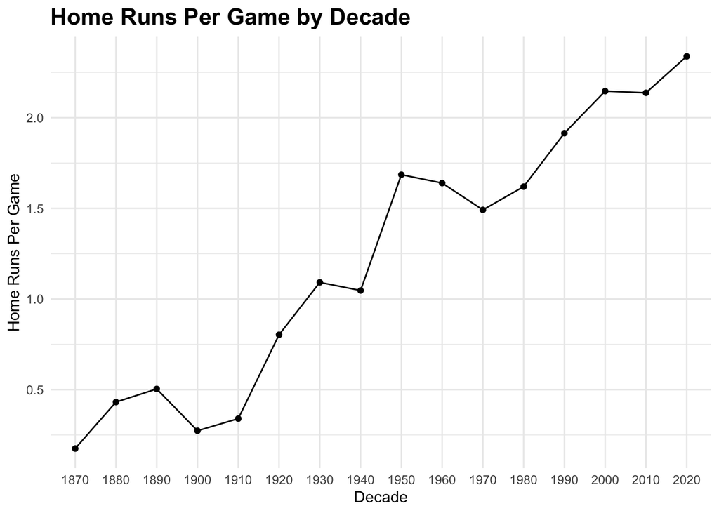

```r
# graph of home runs by decade
ggplot(home_run_by_decade, aes(decade, hrpg))+
  geom_point()+
  geom_line(aes(group = 1))+
  theme_minimal()+
  labs(
    title = "Home Runs Per Game by Decade",
    x = "Decade",
    y = "Home Runs Per Game"
  ) +
  theme(
    plot.title = element_text(face = "bold", size = 16)
  )
```

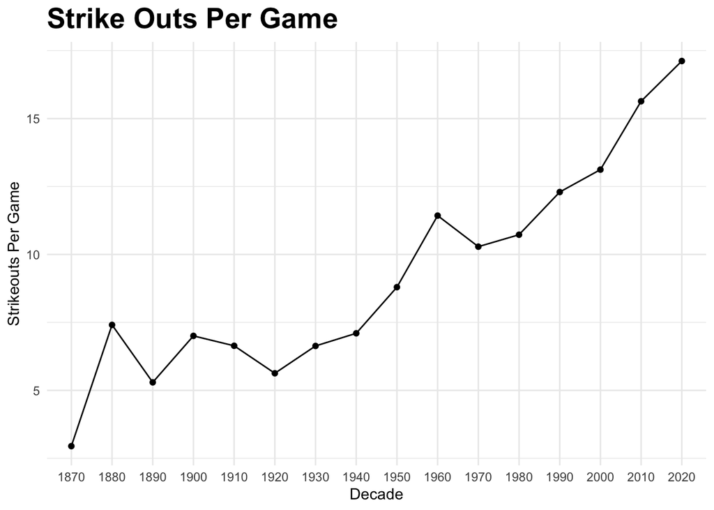

```r
# strike outs per game by decade
ggplot(home_run_by_decade, aes(decade, kpg)) +
  geom_point() +
  geom_line(group = 1) +
  theme_minimal() +
  labs(
    title = "Strike Outs Per Game",
    x = "Decade",
    y = "Strikeouts Per Game"
  ) +
  theme(
    plot.title = element_text(face = "bold", size = 20)
  )
```

Plotted next to one another, you can see the clear correlation between the two over the decades.

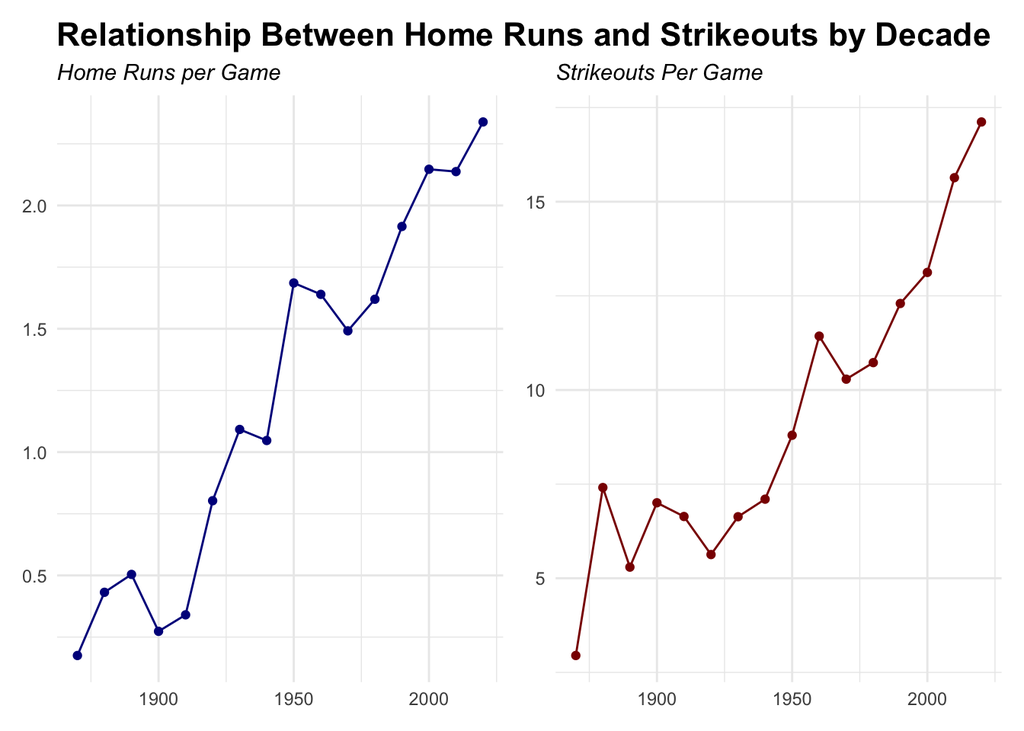

```r
# both mapped together
plot1 = ggplot(home_run_by_decade, aes(as.numeric(decade), hrpg))+
  geom_point(color = "darkblue")+
  geom_line(aes(group = 1), color = "darkblue")+
  theme_minimal()+
  labs(
    title = "Relationship Between Home Runs and Strikeouts by Decade",
    subtitle = "Home Runs per Game",
    x = NULL,
    y = NULL
  ) +
  theme(
    plot.title = element_text(face = "bold", size = 16),
    plot.subtitle = element_text(face = "italic")
  )

plot2 = ggplot(home_run_by_decade, aes(as.numeric(decade), kpg)) +
  geom_point(color = "darkred") +
  geom_line(group = 1, color = "darkred") +
  theme_minimal() +
  labs(
    subtitle = "Strikeouts Per Game",
    x = NULL,
    y = NULL
  ) +
  theme(
    plot.subtitle = element_text(face = "italic")
  )

plot1 + plot2
```

When you look at the percent increase across the decades, again, it is easy to spot the correlation between these two game events. From 1970 onward, the two have mirrored one another very closely.

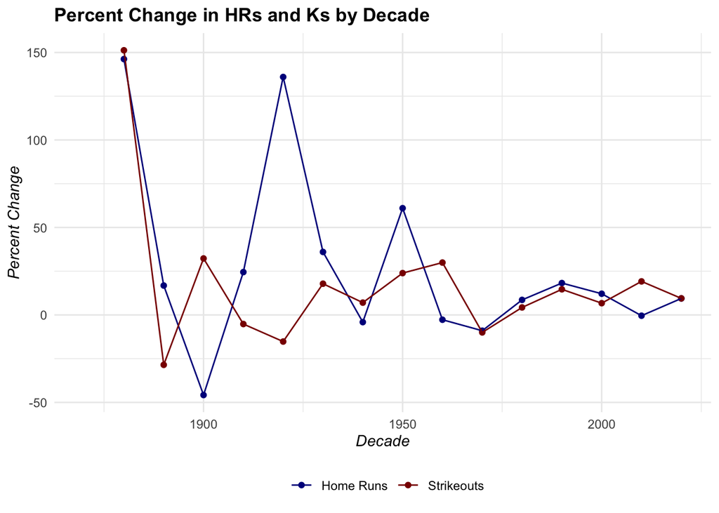

```r
# looking at percent change
home_run_by_decade %>%
  mutate(hr_delta = (hrpg - lag(hrpg))/lag(hrpg)*100,
         k_delta = (kpg - lag(kpg))/lag(kpg)*100) %>%
  select(decade, hr_delta, k_delta) %>%
  mutate(decade = as.numeric(decade)) %>%
  pivot_longer(cols = hr_delta:k_delta, names_to = "stat", values_to = "value") %>%
  ggplot(aes(x = decade, y = value, color = stat))+
  scale_color_manual(values = c("darkblue","darkred"), labels = c("Home Runs", "Strikeouts"))+
  geom_point()+
  geom_line()+
  theme_minimal()+
  labs(
    title = "Percent Change in HRs and Ks by Decade",
    x = "Decade",
    y = "Percent Change",
    color = NULL
  )+
  theme(
    plot.title = element_text(face = "bold"),
    axis.title = element_text(face = "italic"),
    legend.position = "bottom"
  )
```

### The Implementation of the Designated Hitter

*What effect has the introduction of the Designated Hitter (DH) in the American League had in the difference in run scoring between the American and National Leagues?*

Let’s explore this a couple of ways. First, lets look simply at the league wide run scoring. We can find this data in the `Teams` table from the `Lahman` package.

The bar graph below shows the difference in runs

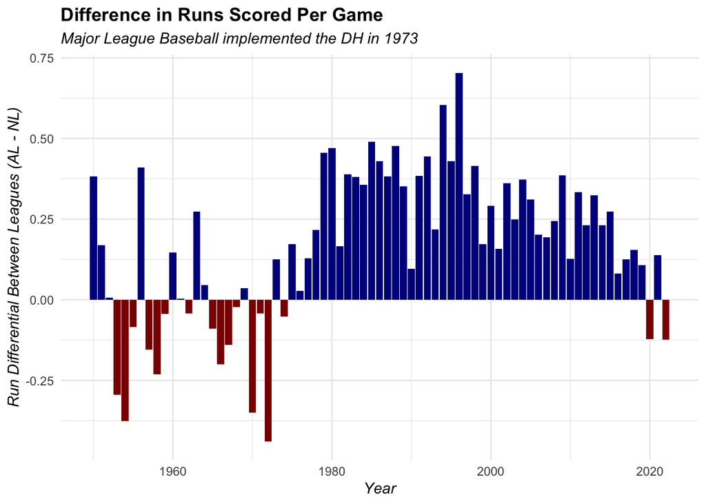

```r
# barplot
Lahman::Teams %>%
  filter(lgID %in% c("NL", "AL")) %>%
  group_by(lgID, yearID) %>%
  summarize(rpg = sum(R)/sum(G)) %>%
  ungroup() %>%
  filter(yearID > 1949) %>%
  arrange(yearID, descending = F) %>%
  pivot_wider(names_from = lgID, values_from = rpg) %>%
  mutate(al_more_than_nl = AL - NL,
         color = if_else(al_more_than_nl > 0, TRUE, FALSE)) %>%
  ggplot(aes(yearID, al_more_than_nl, fill = color))+
  geom_col()+
  scale_fill_manual(values = c("darkred","darkblue"), guide = "none")+
  labs(
    x = "Year",
    y = "Run Differential Between Leagues (AL - NL)",
    title = "Difference in Runs Scored Per Game",
    subtitle = "Major League Baseball implemented the DH in 1973"
  )+
  gg_theme
```

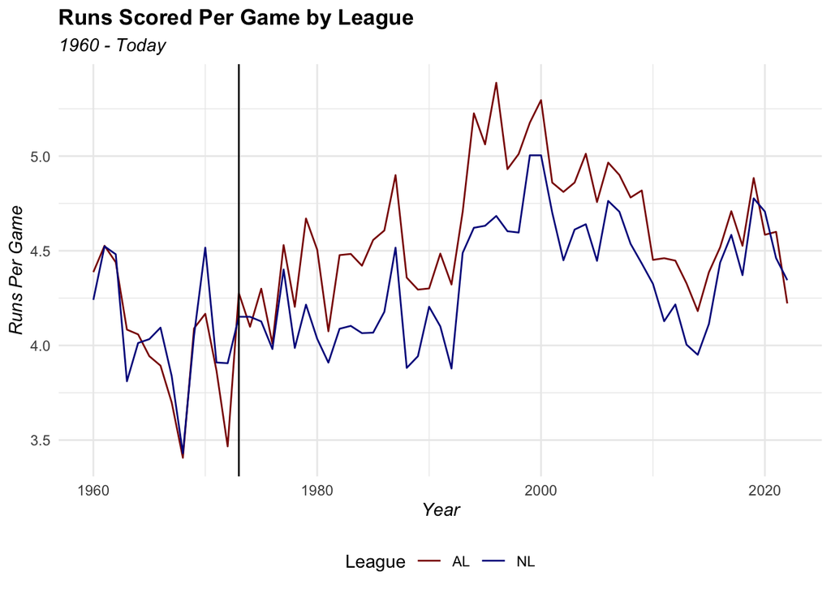

```r
Lahman::Teams %>%
  filter(lgID %in% c("NL", "AL")) %>%
  group_by(lgID, yearID) %>%
  summarize(rpg = (sum(R)/sum(G))) %>%
  ungroup() %>%
  filter(yearID > 1959) %>%
  ggplot(aes(x = yearID, y = rpg, color = lgID))+
  geom_line()+
  scale_color_manual(values = c("darkred", "darkblue"))+
  geom_vline(xintercept = 1973)+
  labs(
    x = "Year",
    y = "Runs Per Game",
    title = "Runs Scored Per Game by League",
    subtitle = "1960 - Today",
    color = "League"
  )+
  gg_theme
```

## Appendix:

Strikouts and home runs plotted on the same axis.

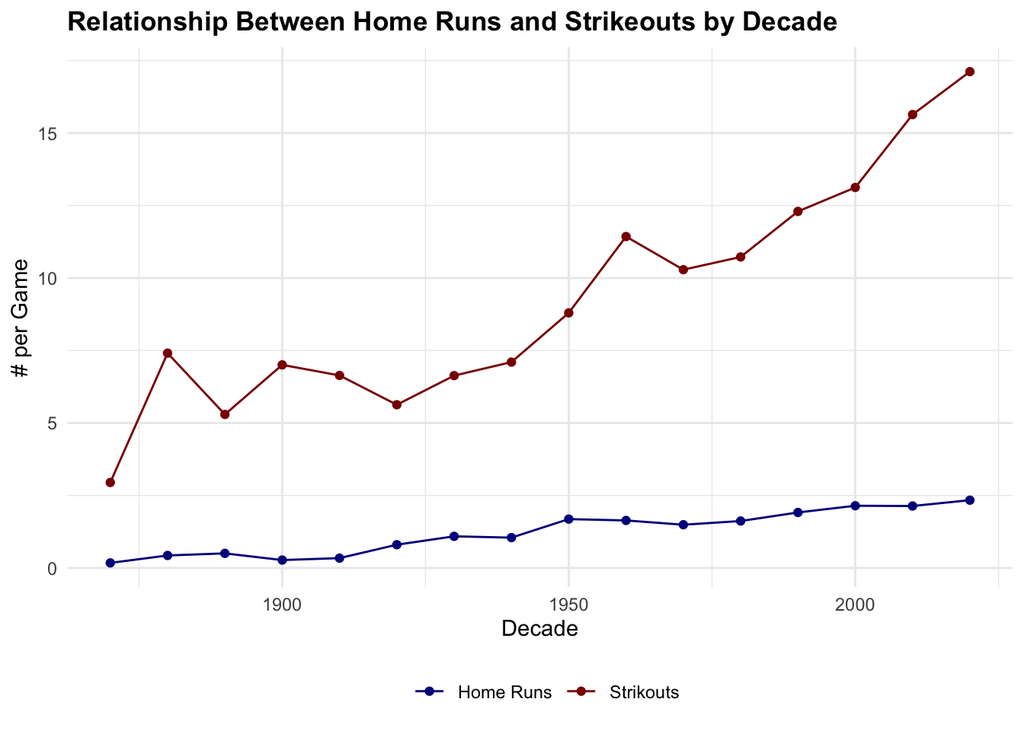

```r
home_run_by_decade %>%
  pivot_longer(cols = hrpg:kpg, names_to = "stat", values_to = "spg") %>%
  mutate(decade = as.numeric(decade)) %>%
  ggplot(aes(decade, spg, color = stat))+
  geom_point()+
  geom_line()+
  scale_color_manual(values = c("darkblue","darkred"), labels = c("Home Runs", "Strikouts"))+
  theme_minimal()+
  labs(
    title = "Relationship Between Home Runs and Strikeouts by Decade",
    x = "Decade",
    y = "# per Game",
    color = NULL
  )+
  theme(
    plot.title = element_text(face = "bold"),
    legend.position = "bottom"
  )
```

Smoothed line with points to demonstrate difference between league run scoring after DH

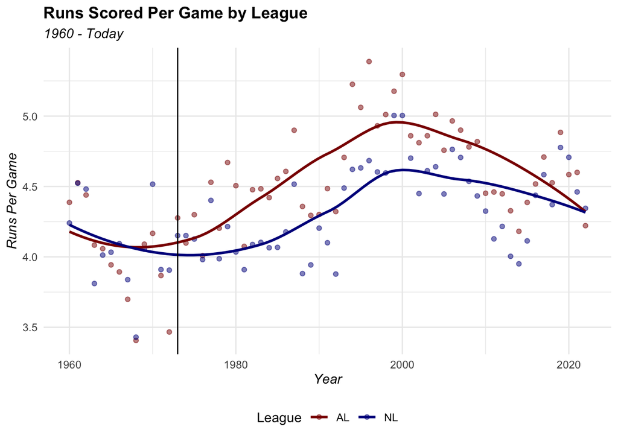

```r
Lahman::Teams %>%
  filter(lgID %in% c("NL", "AL")) %>%
  group_by(lgID, yearID) %>%
  summarize(rpg = (sum(R)/sum(G))) %>%
  ungroup() %>%
  filter(yearID > 1959) %>%
  ggplot(aes(x = yearID, y = rpg, color = lgID))+
  geom_point(alpha = 0.5)+
  geom_smooth(se = F)+
  scale_color_manual(values = c("darkred", "darkblue"))+
  geom_vline(xintercept = 1973)+
  labs(
    x = "Year",
    y = "Runs Per Game",
    title = "Runs Scored Per Game by League",
    subtitle = "1960 - Today",
    color = "League"
  )+
  gg_theme
```